# Practical 8

2. AIC

For AIC, we can simply use the `step` command. You can specify the number of steps yourself.

```r
  step(mo.p)
```

```
## Start:  AIC=-58.32
## lpsa ~ lcavol + lweight + age + lbph + svi + lcp + gleason +
##     pgg45
##
##           Df Sum of Sq    RSS     AIC
## - gleason  1    0.0412 44.204 -60.231
## - pgg45    1    0.5258 44.689 -59.174
## - lcp      1    0.6740 44.837 -58.853
## <none>                 44.163 -58.322
## - age      1    1.5503 45.713 -56.975
## - lbph     1    1.6835 45.847 -56.693
## - lweight  1    3.5861 47.749 -52.749
## - svi      1    4.9355 49.099 -50.046
## - lcavol   1   22.3721 66.535 -20.567
##
## Step:  AIC=-60.23
## lpsa ~ lcavol + lweight + age + lbph + svi + lcp + pgg45
##
##           Df Sum of Sq    RSS     AIC
## - lcp      1    0.6623 44.867 -60.789
## <none>                 44.204 -60.231
## - pgg45    1    1.1920 45.396 -59.650
## - age      1    1.5166 45.721 -58.959
## - lbph     1    1.7053 45.910 -58.560
## - lweight  1    3.5462 47.750 -54.746
## - svi      1    4.8984 49.103 -52.037
## - lcavol   1   23.5039 67.708 -20.872
##
## Step:  AIC=-60.79
## lpsa ~ lcavol + lweight + age + lbph + svi + pgg45
##
##           Df Sum of Sq    RSS     AIC
## - pgg45    1    0.6590 45.526 -61.374
## <none>                 44.867 -60.789
## - age      1    1.2649 46.131 -60.092
## - lbph     1    1.6465 46.513 -59.293
## - lweight  1    3.5647 48.431 -55.373
## - svi      1    4.2503 49.117 -54.009
## - lcavol   1   25.4189 70.285 -19.248
##
## Step:  AIC=-61.37
## lpsa ~ lcavol + lweight + age + lbph + svi
##
##           Df Sum of Sq    RSS     AIC
## <none>                 45.526 -61.374
## - age      1    0.9592 46.485 -61.352
## - lbph     1    1.8568 47.382 -59.497
## - lweight  1    3.2251 48.751 -56.735
## - svi      1    5.9517 51.477 -51.456
## - lcavol   1   28.7665 74.292 -15.871
```

```
##
## Call:
## lm(formula = lpsa ~ lcavol + lweight + age + lbph + svi, data = prostate)
##
## Coefficients:
## (Intercept)       lcavol      lweight          age         lbph          svi
##     0.95100      0.56561      0.42369     -0.01489      0.11184      0.72095
```

Result: variables `age`, `lbph`, `lweight`, `svi`, `lcavol` remain in model.

3. Adjusted $R^2$

For this approach, we can use the `leaps` command. You can specify the number of steps yourself.

```r
moma.p <- model.matrix(mo.p)[,-1]
adju <- leaps(moma.p, prostate$lpsa, method="adjr2")
maxadjr(adju, 10)
```

```
##   1,2,3,4,5,6,8     1,2,3,4,5,8       1,2,3,4,5     1,2,3,4,5,7 1,2,3,4,5,6,7,8
##           0.627           0.626           0.625           0.624           0.623
##   1,2,3,4,5,6,7   1,2,3,4,5,7,8     1,2,3,4,5,6         1,2,4,5       1,2,4,5,8
##           0.623           0.622           0.621           0.621           0.620
```

The best model has highest $R^2_{adj} = 0.627 $. The best 4-predictor model has $R^2_{adj} = 0.621 $. The difference is not very large, from the parsimony criterion, one might choose the smaller model.

3. Mallow’s $C_p$

Again, we use the `leaps` command. For this method, we obtain the $C_p$ values, and plot them against the number of predictors in the model.

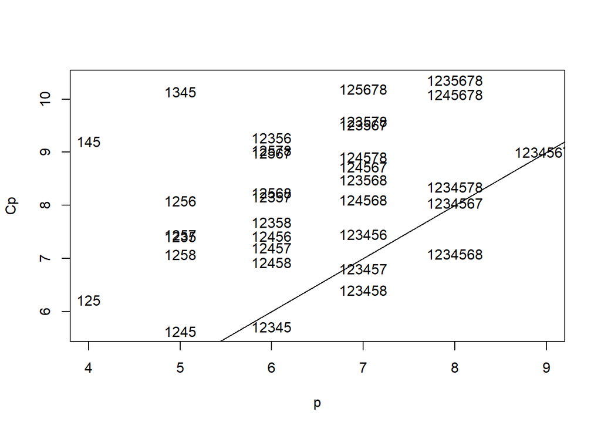

```r
 mallows <-leaps(moma.p, prostate$lpsa)
 Cpplot(mallows)
```

The plot shows that the model with the predidctors lcavol, lweight, age, lbph, svi has the best performance in terms of Mallow’s $C_p$.

## Exercise 3.

The R library `MuMIn` is a convenient took for model selection. Let’s apply R this package to the `prostate` data. Run linear regression with `lpsa` as the response and the other variables as predictors. Use the `dredge()` function on the obtained model, which provides all possible subset regressions. How many models will you get in total? Show the top 15 results. Indicate the model with the lowest AICc, AIC and BIC (by default it gives AICc).

*Hint: run `options(na.action="na.fail")` before `dredge()` function*

```r
  data(prostate)
options(na.action="na.fail") # needed for dredge() function
 lmo <- lm(lpsa ~ ., prostate)
 mmi <- dredge(lmo)
```

```
## Fixed term is "(Intercept)"
```

```r
 nrow(mmi)
```

```
## [1] 256
```

```r
 head(mmi, 15)
```

```
## Global model call: lm(formula = lpsa ~ ., data = prostate)
## ---
## Model selection table
##      (Intrc)       age   glesn    lbph  lcavl      lcp  lwght    pgg45    svi
## 173  0.14550                   0.09009 0.5496          0.3909          0.7117
## 174  0.95100 -0.014890         0.11180 0.5656          0.4237          0.7210
## 169 -0.26810                           0.5516          0.5085          0.6662
## 238  0.98010 -0.017470         0.10580 0.5458          0.4494 0.003528 0.6417
## 233 -0.32690                           0.5310          0.5151 0.003186 0.5976
## 237  0.06646                   0.08303 0.5334          0.4053 0.002529 0.6538
## 176  0.27090 -0.017030 0.11060 0.10690 0.5421          0.4533          0.6943
## 170  0.17190 -0.009287                 0.5619          0.5467          0.6650
## 175 -0.38650           0.07390 0.08468 0.5324          0.4075          0.6931
## 171 -0.94670           0.09889         0.5284          0.5214          0.6448
## 189  0.12060                   0.09156 0.5690 -0.03661 0.3855          0.7664
```

[output cut: 21 more lines]

```r
  mmi <- dredge(lmo, rank = "AIC")
```

```
## Fixed term is "(Intercept)"
```

```r
 head(mmi, 15)
```

```
## Global model call: lm(formula = lpsa ~ ., data = prostate)
## ---
## Model selection table
##      (Intrc)       age   glesn    lbph  lcavl      lcp  lwght    pgg45    svi
## 174  0.95100 -0.014890         0.11180 0.5656          0.4237          0.7210
## 173  0.14550                   0.09009 0.5496          0.3909          0.7117
## 238  0.98010 -0.017470         0.10580 0.5458          0.4494 0.003528 0.6417
## 169 -0.26810                           0.5516          0.5085          0.6662
## 176  0.27090 -0.017030 0.11060 0.10690 0.5421          0.4533          0.6943
## 254  0.95390 -0.019340         0.10770 0.5916 -0.10450 0.4483 0.005318 0.7577
## 237  0.06646                   0.08303 0.5334          0.4053 0.002529 0.6538
## 233 -0.32690                           0.5310          0.5151 0.003186 0.5976
## 175 -0.38650           0.07390 0.08468 0.5324          0.4075          0.6931
## 190  0.93490 -0.015110         0.11380 0.5876 -0.04118 0.4181          0.7826
## 189  0.12060                   0.09156 0.5690 -0.03661 0.3855          0.7664
```

[output cut: 21 more lines]

```r
mmi <- dredge(lmo, rank = "BIC")
```

```
## Fixed term is "(Intercept)"
```

```r
 head(mmi, 15)
```

```
## Global model call: lm(formula = lpsa ~ ., data = prostate)
## ---
## Model selection table
##      (Intrc)       age   glesn    lbph  lcavl      lcp  lwght    pgg45    svi
## 169 -0.26810                           0.5516          0.5085          0.6662
## 173  0.14550                   0.09009 0.5496          0.3909          0.7117
## 141  1.52800                   0.14850 0.5736                          0.7435
## 233 -0.32690                           0.5310          0.5151 0.003186 0.5976
## 170  0.17190 -0.009287                 0.5619          0.5467          0.6650
## 171 -0.94670           0.09889         0.5284          0.5214          0.6448
## 185 -0.29310                           0.5670 -0.02893 0.5058          0.7088
## 174  0.95100 -0.014890         0.11180 0.5656          0.4237          0.7210
## 41  -0.30260                           0.6775          0.5109
## 237  0.06646                   0.08303 0.5334          0.4053 0.002529 0.6538
## 175 -0.38650           0.07390 0.08468 0.5324          0.4075          0.6931
```

[output cut: 21 more lines]

There are $2^8 = 256$ possible subset regressions. The model with lbph, lcavl, lwght, and svi has the lowest AICc value. AICc is often used in case of small sample sizes or situation with many model parameters compared to sample size. AICc uses a heavier penalty compared to ordinary AIC. Next, the model with age, lbph, lcavl, lwght, and svi has the lowest AIC value. Finally, the model with lcavl, lwght, and svi has the lowest BIC value.

## Exercise 4.

(Exercise 22.1, Fox): Sampling from the standard normal distribution, *independently* generate 500 observations for 101 variables. Call the first of these variables the response variable $Y$ and the other variables the predictors $X_1, X_2 , ..., X_{100}$.

1. Perform a linear least-squares regression of $Y$ on $X_1, X_2 , ..., X_{100}$. Are any of the individual regression coefficients “statistically significant”? Is the omnibus F-statistic for the regression “statistically significant”? Is this what you expected to observe (i.e., what are the “true” values of the regression coefficients $\beta_1, \beta_2 , ..., \beta_{100}$). Based on your answer, check the Type-I error rate (the proportion of falsely rejected null hypotheses).

```r
#Data generation
YX <- matrix(NA, 500, 101)
 set.seed(10824)
 for (i in 1:101) YX[,i] <- rnorm(500)
 X <- YX[,2:101]
 Y <- YX[,1]
 mydata <- data.frame(Y, X)
 #Regressing Y against all the predictors
 lm.sim <- lm(Y ~ . , mydata)
 summary(lm.sim)
```

```
##
## Call:
## lm(formula = Y ~ ., data = mydata)
##
## Residuals:
##     Min      1Q  Median      3Q     Max
## -2.4332 -0.6064 -0.0078  0.5973  3.4405
##
## Coefficients:
##              Estimate Std. Error t value Pr(>|t|)
## (Intercept) -0.016211   0.051450  -0.315  0.75286
## X1           0.055039   0.054853   1.003  0.31628
## X2          -0.102991   0.049575  -2.077  0.03840 *
## X3           0.031038   0.051517   0.602  0.54720
## X4           0.056812   0.053433   1.063  0.28832
## X5          -0.040044   0.050904  -0.787  0.43196
## X6           0.034652   0.053371   0.649  0.51653
## X7           0.011179   0.053914   0.207  0.83584
## X8          -0.029267   0.051499  -0.568  0.57016
## X9           0.070320   0.053112   1.324  0.18627
## X10          0.047309   0.052108   0.908  0.36448
## X11         -0.004763   0.051479  -0.093  0.92632
## X12          0.034900   0.051432   0.679  0.49781
## X13         -0.032506   0.053132  -0.612  0.54102
## X14          0.056518   0.051002   1.108  0.26846
## X15          0.068999   0.051990   1.327  0.18522
## X16         -0.057063   0.050897  -1.121  0.26290
## X17          0.097179   0.053145   1.829  0.06821 .
## X18         -0.020387   0.050802  -0.401  0.68841
## X19          0.010983   0.051784   0.212  0.83215
## X20         -0.001151   0.051155  -0.023  0.98206
## X21          0.035280   0.055269   0.638  0.52362
## X22         -0.007718   0.051614  -0.150  0.88121
## X23         -0.006551   0.052824  -0.124  0.90136
## X24          0.113674   0.051318   2.215  0.02732 *
## X25         -0.033625   0.055295  -0.608  0.54346
## X26          0.007644   0.049134   0.156  0.87645
## X27         -0.023383   0.053191  -0.440  0.66046
## X28          0.035026   0.054252   0.646  0.51890
## X29         -0.068686   0.051339  -1.338  0.18169
```

[output cut: 62 more lines]

```
## X92         -0.007512   0.051478  -0.146  0.88406
## X93          0.031020   0.049424   0.628  0.53060
## X94          0.036506   0.048982   0.745  0.45652
## X95          0.025307   0.048714   0.520  0.60370
## X96          0.030752   0.049203   0.625  0.53233
## X97         -0.038181   0.049089  -0.778  0.43716
## X98         -0.095035   0.051787  -1.835  0.06724 .
## X99         -0.113019   0.051627  -2.189  0.02916 *
## X100        -0.006431   0.051243  -0.125  0.90020
## ---
## Signif. codes:  0 '***' 0.001 '**' 0.01 '*' 0.05 '.' 0.1 ' ' 1
##
## Residual standard error: 1.037 on 399 degrees of freedom
## Multiple R-squared:  0.2257, Adjusted R-squared:  0.0316
## F-statistic: 1.163 on 100 and 399 DF,  p-value: 0.159
```

The omnibus F-test produces a p-value of 0.1590091, which is not “statistically significant”. However, few of the slope coefficients are “statistically significant” at the .05 level for a two-sided test. Note that the true values of the $\beta_j$’s are all 0, and so the null hypotheses (i.e., $H_0: \beta_j=0$) are all correct. This is due to the independent generation of the variables. In general, we expect each null hypothesis to produce a Type-I error (rejecting a true $H_0$) 5 percent of the time. The omnibus test didn’t produce one of these unlucky results. We would expect about 5 of the 100 coefficients to be “statistically significant” by chance. The observed number of “wrong” rejection of the null hypothesis may differ.

```r
Pvals <- coef(summary(lm.sim))[2:101,4]
Pvals[Pvals<0.05]
```

```
##          X2         X24         X33         X37         X39         X64
## 0.038397348 0.027317955 0.005025849 0.018684859 0.033650859 0.033200574
##         X67         X99
## 0.031499530 0.029164246
```

```r
sum(Pvals < 0.05)
```

```
## [1] 8
```

2. Retain the three predictors in part a) that have the largest absolute t-values. Next, regress $Y$ only on these variables. Are the individual coefficients “statistically significant”? What about the omnibus F? What happens to the p-values compared to part a)?

```r
Tvals <- abs(coef(summary(lm.sim))[2:101,3])
selected.vars <- order(Tvals, decreasing=TRUE)[1:3] #select the three variables with highest absolute t-value
selected.vars
```

```
## [1] 33 37 24
```

```r
lm.sim.sel <- lm(Y ~ X[,selected.vars]) # Linear regression with only three variables
summary(lm.sim.sel)
```

```
##
## Call:
## lm(formula = Y ~ X[, selected.vars])
##
## Residuals:
##     Min      1Q  Median      3Q     Max
## -3.2072 -0.6687 -0.0190  0.6836  3.5725
##
## Coefficients:
##                     Estimate Std. Error t value Pr(>|t|)
## (Intercept)         -0.03591    0.04658  -0.771  0.44109
## X[, selected.vars]1 -0.12656    0.04777  -2.649  0.00832 **
## X[, selected.vars]2  0.11369    0.04488   2.533  0.01161 *
## X[, selected.vars]3  0.08989    0.04636   1.939  0.05306 .
## ---
## Signif. codes:  0 '***' 0.001 '**' 0.01 '*' 0.05 '.' 0.1 ' ' 1
##
## Residual standard error: 1.038 on 496 degrees of freedom
## Multiple R-squared:  0.03655,    Adjusted R-squared:  0.03072
## F-statistic: 6.272 on 3 and 496 DF,  p-value: 0.0003491
```

Now omnibus F-test is highly significant. The P-values for individual coefficients change a bit.

c). Using any method of variables selection (stepwise regression or subset regression with any criterion), find the “best” model with three explanatory variables. Obtain the individual t-statistics and omnibus F for this model. How do these tests compare to those in part a?

First, let’s use the function `regsubsets`, because leaps does not allow this many regressors. Below we go through all models with 1, 2, or 3 regressors, and report the best model.

```r
library(leaps)
b <- regsubsets(Y~., data=mydata, nbest=1, nvmax=3, intercept=TRUE, method=c("exhaustive"), really.big=TRUE)
rs <- summary(b)
rs$cp # Cp values for best models with 1, 2, and 3 regressors
```

```
## [1] 11.213667  5.494140  1.690845
```

```r
rs$adjr2 # Adjr2 values for best models with 1, 2, and 3 regressors
```

```
## [1] 0.01368325 0.02674014 0.03610839
```

```r
(sel_reg <- names(rs$which[3,])[rs$which[3,]]) # Names of regressors of best fitting 3-regressor model
```

```
## [1] "(Intercept)" "X33"         "X37"         "X67"
```

```r
sel_reg <- (substring(sel_reg[-1],2,3))
sel_reg <- as.numeric(sel_reg)
lm.sim.sel1 <- lm(Y ~ X[,sel_reg])
summary(lm.sim.sel1)
```

```
##
## Call:
## lm(formula = Y ~ X[, sel_reg])
##
## Residuals:
##     Min      1Q  Median      3Q     Max
## -3.1068 -0.6834 -0.0118  0.6934  3.4436
##
## Coefficients:
##               Estimate Std. Error t value Pr(>|t|)
## (Intercept)   -0.03189    0.04643  -0.687  0.49245
## X[, sel_reg]1 -0.13238    0.04769  -2.776  0.00571 **
## X[, sel_reg]2  0.10833    0.04486   2.415  0.01611 *
## X[, sel_reg]3  0.11796    0.04608   2.560  0.01076 *
## ---
## Signif. codes:  0 '***' 0.001 '**' 0.01 '*' 0.05 '.' 0.1 ' ' 1
##
## Residual standard error: 1.035 on 496 degrees of freedom
## Multiple R-squared:  0.0419, Adjusted R-squared:  0.03611
## F-statistic: 7.231 on 3 and 496 DF,  p-value: 9.326e-05
```

4. Using any method of model selection, find the “best” model for these data. How many regressors will be in this model? How does this model compare to the true model that generated the data?

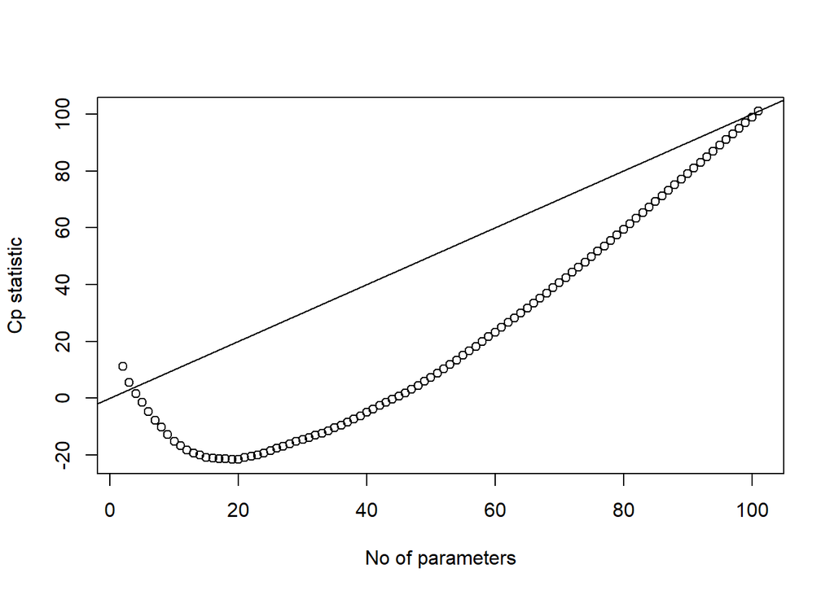

```r
b2 <- regsubsets(Y ~ ., data=mydata, nbest=1, nvmax=100, intercept=TRUE, method=c("forward"), really.big=TRUE)
rs2 <- summary(b2)
plot(2:101,rs2$cp,xlab="No of parameters",ylab="Cp statistic")
abline(a=0, b=1)
```

```r
(1:length(rs2$cp))[rs2$cp==min(rs2$cp)]
```

```
## [1] 18
```

The model should not contain any regressors, because the response and the predictors are independently generated.

5. *Validation*: Generate a new set of 500 observations as in part a, and use that new dataset to validate the models that you selected in part b (three variables). What do you conclude?

```r
newX <- matrix(NA, 500, 100)
for (i in 1:100) newX[,i] <- rnorm(500)
newY <- rnorm(500)
lm.sim.val <- lm(newY ~ newX[,selected.vars])
summary(lm.sim.val)
```

```
##
## Call:
## lm(formula = newY ~ newX[, selected.vars])
##
## Residuals:
##      Min       1Q   Median       3Q      Max
## -2.75481 -0.64471  0.00249  0.66447  2.69510
##
## Coefficients:
##                         Estimate Std. Error t value Pr(>|t|)
## (Intercept)            -0.033918   0.044252  -0.766    0.444
## newX[, selected.vars]1  0.001467   0.045151   0.032    0.974
## newX[, selected.vars]2  0.040092   0.043819   0.915    0.361
## newX[, selected.vars]3  0.103655   0.045126   2.297    0.022 *
## ---
## Signif. codes:  0 '***' 0.001 '**' 0.01 '*' 0.05 '.' 0.1 ' ' 1
##
## Residual standard error: 0.9875 on 496 degrees of freedom
## Multiple R-squared:  0.01211,    Adjusted R-squared:  0.00614
## F-statistic: 2.028 on 3 and 496 DF,  p-value: 0.1091
```

This, of course, will show that the model is useless. We are studying just independent noise.

## Exercise 5.

Let’s use `Hitters` dataset provided by the `ISLR` package. This is a data set that contains number of hits, homeruns, RBIs, and other information for 322 major league baseball players.

```r
hitters <- na.omit(ISLR::Hitters)
```

1. Fit the model with `Salary` as the response variable. Perform a best subset search using `regsubsets`, and fit up to 19 variables. Show the “star”-table based on the number of predictors in the model (simpy run the summary of `regsubsets()` object, see the code). Which variables will be in the best 4-predictor model.

```r
dim(hitters)
```

```
## [1] 263  20
```

```r
lm_hitters <- lm(Salary ~ ., data = hitters)
summary(lm_hitters)
```

```
##
## Call:
## lm(formula = Salary ~ ., data = hitters)
##
## Residuals:
##     Min      1Q  Median      3Q     Max
## -907.62 -178.35  -31.11  139.09 1877.04
##
## Coefficients:
##               Estimate Std. Error t value Pr(>|t|)
## (Intercept)  163.10359   90.77854   1.797 0.073622 .
## AtBat         -1.97987    0.63398  -3.123 0.002008 **
## Hits           7.50077    2.37753   3.155 0.001808 **
## HmRun          4.33088    6.20145   0.698 0.485616
## Runs          -2.37621    2.98076  -0.797 0.426122
## RBI           -1.04496    2.60088  -0.402 0.688204
## Walks          6.23129    1.82850   3.408 0.000766 ***
## Years         -3.48905   12.41219  -0.281 0.778874
## CAtBat        -0.17134    0.13524  -1.267 0.206380
## CHits          0.13399    0.67455   0.199 0.842713
## CHmRun        -0.17286    1.61724  -0.107 0.914967
## CRuns          1.45430    0.75046   1.938 0.053795 .
## CRBI           0.80771    0.69262   1.166 0.244691
## CWalks        -0.81157    0.32808  -2.474 0.014057 *
## LeagueN       62.59942   79.26140   0.790 0.430424
## DivisionW   -116.84925   40.36695  -2.895 0.004141 **
## PutOuts        0.28189    0.07744   3.640 0.000333 ***
## Assists        0.37107    0.22120   1.678 0.094723 .
## Errors        -3.36076    4.39163  -0.765 0.444857
## NewLeagueN   -24.76233   79.00263  -0.313 0.754218
## ---
## Signif. codes:  0 '***' 0.001 '**' 0.01 '*' 0.05 '.' 0.1 ' ' 1
##
## Residual standard error: 315.6 on 243 degrees of freedom
## Multiple R-squared:  0.5461, Adjusted R-squared:  0.5106
## F-statistic: 15.39 on 19 and 243 DF,  p-value: < 2.2e-16
```

```r
#All possible subsets
best_subset_hitters <- regsubsets(Salary ~ ., hitters, nvmax = 19)
summary(best_subset_hitters)
```

```
## Subset selection object
## Call: regsubsets.formula(Salary ~ ., hitters, nvmax = 19)
## 19 Variables  (and intercept)
##            Forced in Forced out
## AtBat          FALSE      FALSE
## Hits           FALSE      FALSE
## HmRun          FALSE      FALSE
## Runs           FALSE      FALSE
## RBI            FALSE      FALSE
## Walks          FALSE      FALSE
## Years          FALSE      FALSE
## CAtBat         FALSE      FALSE
## CHits          FALSE      FALSE
## CHmRun         FALSE      FALSE
## CRuns          FALSE      FALSE
## CRBI           FALSE      FALSE
## CWalks         FALSE      FALSE
## LeagueN        FALSE      FALSE
## DivisionW      FALSE      FALSE
## PutOuts        FALSE      FALSE
## Assists        FALSE      FALSE
## Errors         FALSE      FALSE
## NewLeagueN     FALSE      FALSE
## 1 subsets of each size up to 19
## Selection Algorithm: exhaustive
##           AtBat Hits HmRun Runs RBI Walks Years CAtBat CHits CHmRun CRuns CRBI
## 1  ( 1 )  " "   " "  " "   " "  " " " "   " "   " "    " "   " "    " "   "*"
## 2  ( 1 )  " "   "*"  " "   " "  " " " "   " "   " "    " "   " "    " "   "*"
## 3  ( 1 )  " "   "*"  " "   " "  " " " "   " "   " "    " "   " "    " "   "*"
## 4  ( 1 )  " "   "*"  " "   " "  " " " "   " "   " "    " "   " "    " "   "*"
## 5  ( 1 )  "*"   "*"  " "   " "  " " " "   " "   " "    " "   " "    " "   "*"
## 6  ( 1 )  "*"   "*"  " "   " "  " " "*"   " "   " "    " "   " "    " "   "*"
## 7  ( 1 )  " "   "*"  " "   " "  " " "*"   " "   "*"    "*"   "*"    " "   " "
## 8  ( 1 )  "*"   "*"  " "   " "  " " "*"   " "   " "    " "   "*"    "*"   " "
## 9  ( 1 )  "*"   "*"  " "   " "  " " "*"   " "   "*"    " "   " "    "*"   "*"
## 10  ( 1 ) "*"   "*"  " "   " "  " " "*"   " "   "*"    " "   " "    "*"   "*"
## 11  ( 1 ) "*"   "*"  " "   " "  " " "*"   " "   "*"    " "   " "    "*"   "*"
## 12  ( 1 ) "*"   "*"  " "   "*"  " " "*"   " "   "*"    " "   " "    "*"   "*"
## 13  ( 1 ) "*"   "*"  " "   "*"  " " "*"   " "   "*"    " "   " "    "*"   "*"
## 14  ( 1 ) "*"   "*"  "*"   "*"  " " "*"   " "   "*"    " "   " "    "*"   "*"
```

[output cut: 10 more lines]

```
## 5  ( 1 )  " "    " "     "*"       "*"     " "     " "    " "
## 6  ( 1 )  " "    " "     "*"       "*"     " "     " "    " "
## 7  ( 1 )  " "    " "     "*"       "*"     " "     " "    " "
## 8  ( 1 )  "*"    " "     "*"       "*"     " "     " "    " "
## 9  ( 1 )  "*"    " "     "*"       "*"     " "     " "    " "
## 10  ( 1 ) "*"    " "     "*"       "*"     "*"     " "    " "
## 11  ( 1 ) "*"    "*"     "*"       "*"     "*"     " "    " "
## 12  ( 1 ) "*"    "*"     "*"       "*"     "*"     " "    " "
## 13  ( 1 ) "*"    "*"     "*"       "*"     "*"     "*"    " "
## 14  ( 1 ) "*"    "*"     "*"       "*"     "*"     "*"    " "
## 15  ( 1 ) "*"    "*"     "*"       "*"     "*"     "*"    " "
## 16  ( 1 ) "*"    "*"     "*"       "*"     "*"     "*"    " "
## 17  ( 1 ) "*"    "*"     "*"       "*"     "*"     "*"    "*"
## 18  ( 1 ) "*"    "*"     "*"       "*"     "*"     "*"    "*"
## 19  ( 1 ) "*"    "*"     "*"       "*"     "*"     "*"    "*"
```

2. Now perform the complete model using a training vs. testing validation approach. Randomly divide the sample into training and testing sets. Using the learned statisitcs, determine the preferred model. These statistics (Malow’s $C_p$ and $R^2_{adj}$) are contained in the output provided by the `regsubsets` function. Extract this information and plot them against the number of predictors. Looking at the plots, how many predictors are optimal based on each metric?

```r
# create training - testing data
set.seed(1)
sample <- sample(c(TRUE, FALSE), nrow(hitters), replace = T, prob = c(0.6,0.4))
train <- hitters[sample, ]
test <- hitters[!sample, ]

# perform best subset selection
best_subset <- regsubsets(Salary ~ ., train, nvmax = 19)
results <- summary(best_subset)
results
```

```
## Subset selection object
## Call: regsubsets.formula(Salary ~ ., train, nvmax = 19)
## 19 Variables  (and intercept)
##            Forced in Forced out
## AtBat          FALSE      FALSE
## Hits           FALSE      FALSE
## HmRun          FALSE      FALSE
## Runs           FALSE      FALSE
## RBI            FALSE      FALSE
## Walks          FALSE      FALSE
## Years          FALSE      FALSE
## CAtBat         FALSE      FALSE
## CHits          FALSE      FALSE
## CHmRun         FALSE      FALSE
## CRuns          FALSE      FALSE
## CRBI           FALSE      FALSE
## CWalks         FALSE      FALSE
## LeagueN        FALSE      FALSE
## DivisionW      FALSE      FALSE
## PutOuts        FALSE      FALSE
## Assists        FALSE      FALSE
## Errors         FALSE      FALSE
## NewLeagueN     FALSE      FALSE
## 1 subsets of each size up to 19
## Selection Algorithm: exhaustive
##           AtBat Hits HmRun Runs RBI Walks Years CAtBat CHits CHmRun CRuns CRBI
## 1  ( 1 )  " "   " "  " "   " "  " " " "   " "   " "    " "   " "    "*"   " "
## 2  ( 1 )  " "   "*"  " "   " "  " " " "   " "   " "    " "   " "    " "   "*"
## 3  ( 1 )  " "   " "  " "   "*"  " " " "   " "   "*"    "*"   " "    " "   " "
## 4  ( 1 )  " "   " "  " "   "*"  " " " "   " "   "*"    "*"   " "    " "   " "
## 5  ( 1 )  " "   "*"  " "   " "  " " " "   " "   "*"    "*"   "*"    " "   " "
## 6  ( 1 )  " "   "*"  " "   " "  " " "*"   " "   "*"    "*"   "*"    " "   " "
## 7  ( 1 )  "*"   "*"  " "   " "  " " "*"   " "   "*"    "*"   "*"    " "   " "
## 8  ( 1 )  "*"   "*"  " "   " "  " " "*"   " "   "*"    "*"   "*"    " "   " "
## 9  ( 1 )  "*"   "*"  " "   " "  " " "*"   " "   "*"    "*"   "*"    " "   " "
## 10  ( 1 ) "*"   "*"  " "   " "  " " "*"   " "   "*"    "*"   "*"    " "   " "
## 11  ( 1 ) "*"   "*"  " "   " "  " " "*"   " "   "*"    "*"   "*"    " "   " "
## 12  ( 1 ) "*"   "*"  " "   " "  " " "*"   " "   "*"    "*"   "*"    " "   "*"
## 13  ( 1 ) "*"   "*"  " "   " "  " " "*"   " "   "*"    "*"   "*"    " "   "*"
## 14  ( 1 ) "*"   "*"  " "   " "  " " "*"   " "   "*"    "*"   "*"    "*"   "*"
```

[output cut: 10 more lines]

```
## 5  ( 1 )  " "    " "     " "       "*"     " "     " "    " "
## 6  ( 1 )  " "    " "     " "       "*"     " "     " "    " "
## 7  ( 1 )  " "    " "     " "       "*"     " "     " "    " "
## 8  ( 1 )  "*"    " "     " "       "*"     " "     " "    " "
## 9  ( 1 )  "*"    " "     "*"       "*"     " "     " "    " "
## 10  ( 1 ) "*"    "*"     "*"       "*"     " "     " "    " "
## 11  ( 1 ) "*"    "*"     "*"       "*"     " "     " "    "*"
## 12  ( 1 ) "*"    "*"     "*"       "*"     " "     " "    "*"
## 13  ( 1 ) "*"    "*"     "*"       "*"     " "     "*"    "*"
## 14  ( 1 ) "*"    "*"     "*"       "*"     " "     "*"    "*"
## 15  ( 1 ) "*"    "*"     "*"       "*"     "*"     "*"    "*"
## 16  ( 1 ) "*"    "*"     "*"       "*"     "*"     "*"    "*"
## 17  ( 1 ) "*"    "*"     "*"       "*"     "*"     "*"    "*"
## 18  ( 1 ) "*"    "*"     "*"       "*"     "*"     "*"    "*"
## 19  ( 1 ) "*"    "*"     "*"       "*"     "*"     "*"    "*"
```

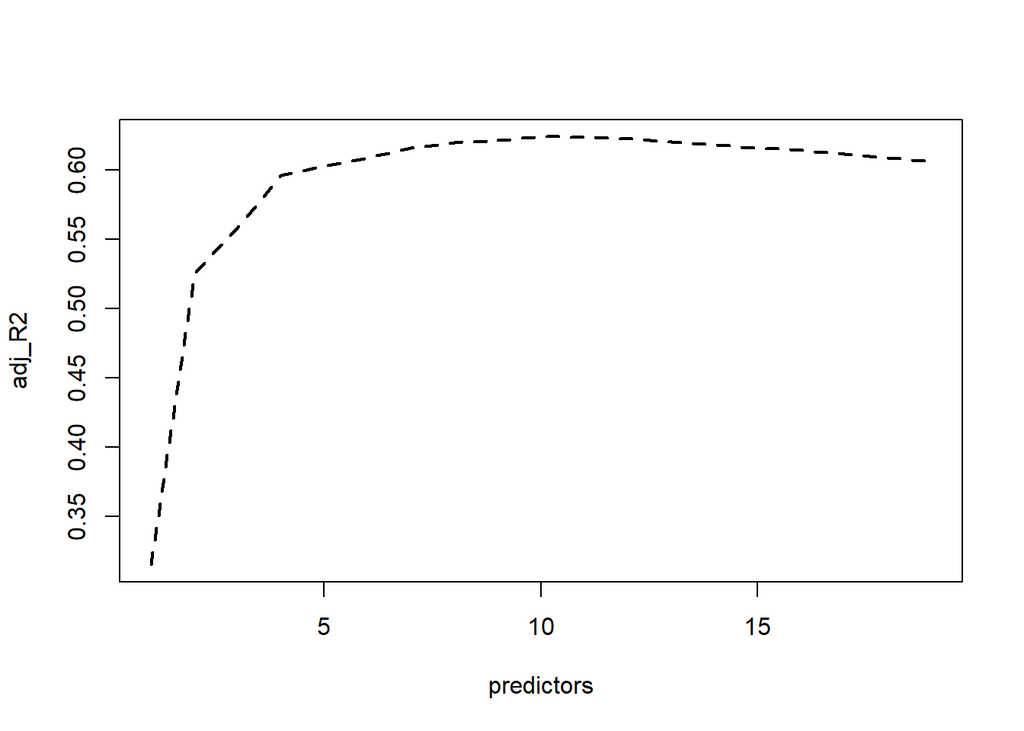

```r
adj_R2 <- results$adjr2
Cp <- results$cp
BIC <- results$bic
predictors <- c(1:19)
plot(adj_R2 ~ predictors, type="l", lty = 2, lwd = 2)
```

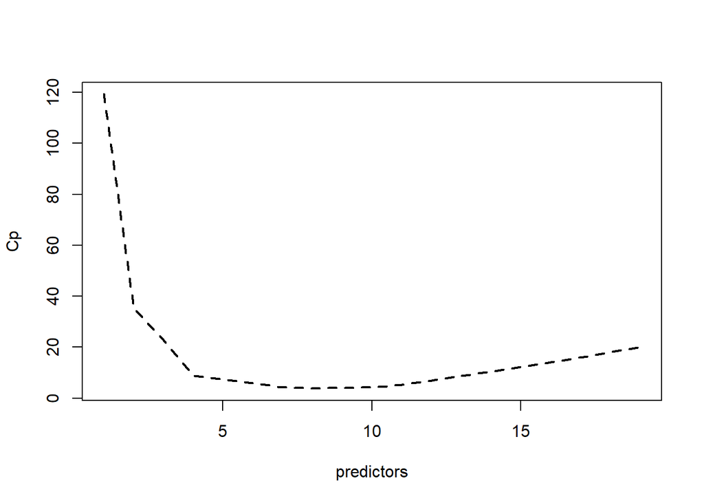

```r
plot(Cp ~ predictors, type="l", lty = 2, lwd = 2)
```

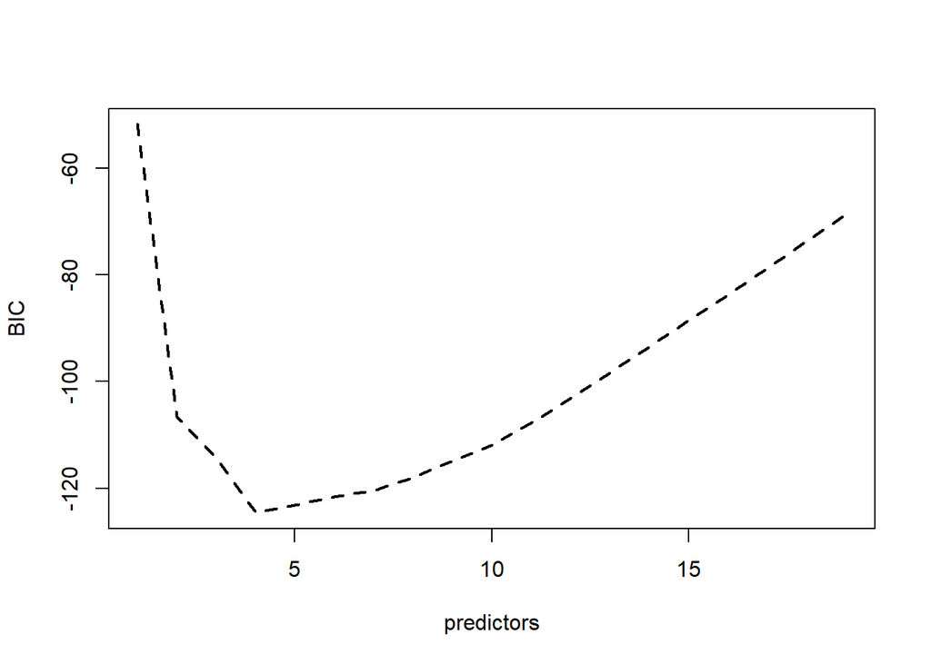

```r
plot(BIC ~ predictors, type="l", lty = 2, lwd = 2)
```

```r
which.max(results$adjr2)
```

```
## [1] 10
```

```r
which.min(results$bic)
```

```
## [1] 4
```

```r
which.min(results$cp)
```

```
## [1] 8
```

```r
#coef(best_subset, which.max(results$adjr2))
#coef(best_subset, which.min(results$bic))
#coef(best_subset, which.min(results$cp))
```

The adjusted $R^2$ statistic suggests the 10 variable model is preferred, the BIC statistic suggests the 4 variable model, and the $C_p$ suggests the 8 variable model. Overall, 4 variable model seems to be the most optimal, because the difference between the adjusted $R^2$ (or $C_p$) between 4 variable or 10 (or 8), is negligible.

3. Fit the model using the using 4-variable model, according to the part b), based on the training data. Now, using the testing data, calculate the predictions of `Salary`. Plot the predicted and the observed values. Provide the correlation and the Root Means Squared Errors.

```r
# Selected 4-variables
(selected_variables <- colnames(results$outmat)[results$outmat[4,]=="*"])
```

```
## [1] "Runs"    "CAtBat"  "CHits"   "PutOuts"
```

```r
lm_training_hitters <- lm(Salary ~ Runs + CAtBat + CHits + PutOuts, data = train)
summary(lm_training_hitters)
```

```
##
## Call:
## lm(formula = Salary ~ Runs + CAtBat + CHits + PutOuts, data = train)
##
## Residuals:
##     Min      1Q  Median      3Q     Max
## -660.74 -133.56  -14.06  146.42  919.57
##
## Coefficients:
##              Estimate Std. Error t value Pr(>|t|)
## (Intercept) -83.11993   59.66332  -1.393 0.165557
## Runs          5.55309    0.95577   5.810 3.40e-08 ***
## CAtBat       -0.47418    0.10098  -4.696 5.79e-06 ***
## CHits         2.05606    0.36635   5.612 8.90e-08 ***
## PutOuts       0.31183    0.07888   3.953 0.000117 ***
## ---
## Signif. codes:  0 '***' 0.001 '**' 0.01 '*' 0.05 '.' 0.1 ' ' 1
##
## Residual standard error: 279.2 on 156 degrees of freedom
## Multiple R-squared:  0.6062, Adjusted R-squared:  0.5961
## F-statistic: 60.03 on 4 and 156 DF,  p-value: < 2.2e-16
```

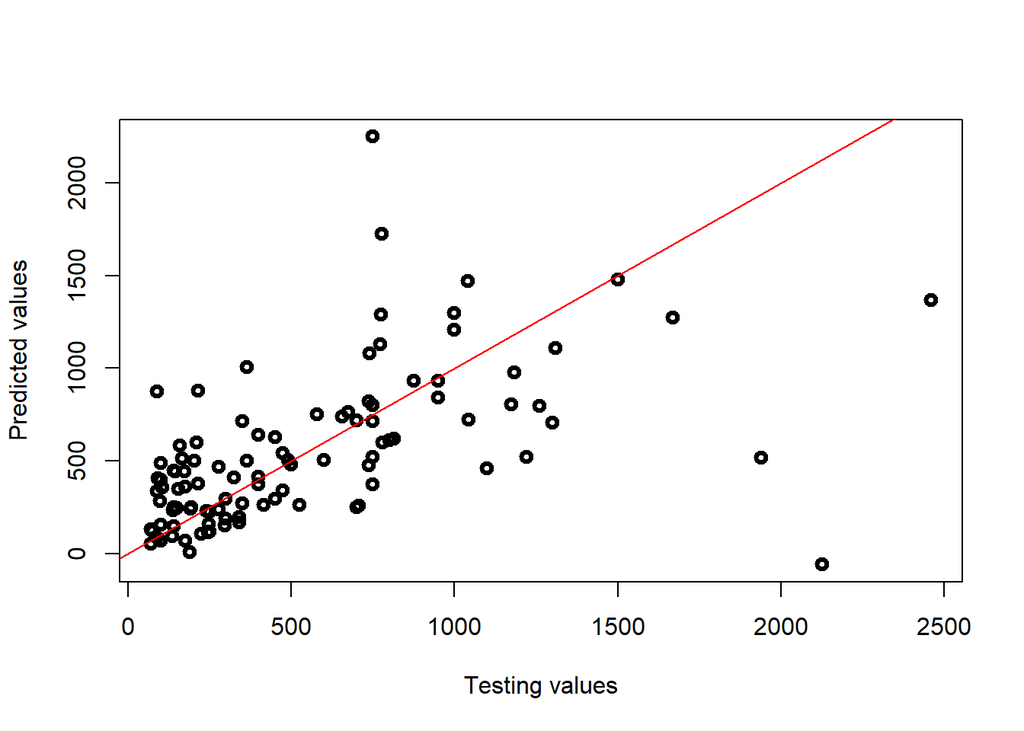

```r
# predicting the target variable
predictions_hitters <- predict(lm_training_hitters, test)

plot(predictions_hitters ~ test$Salary,
     xlab="Testing values", ylab = "Predicted values",
     lwd= 3)
abline(a=0, b=1, col="red")
```

```r
# computing model performance metrics
(R2 <- R2(predictions_hitters, test$Salary))
```

```
## [1] 0.2900291
```

```r
(RMSE <- RMSE(predictions_hitters, test$Salary))
```

```
## [1] 423.6577
```

## Exercise 6 (Homework).

Using `divusa` data (a) Fit regression model with `divorce` as response, and `unemployed`, `femlab`, `marriage`, `birth`, and `military` as predictors. Compute the condition index and interpret their meaning.

```r
g <- lm(divorce ~ unemployed + femlab + marriage + birth + military, data=divusa)
summary(g)
```

```
##
## Call:
## lm(formula = divorce ~ unemployed + femlab + marriage + birth +
##     military, data = divusa)
##
## Residuals:
##     Min      1Q  Median      3Q     Max
## -3.8611 -0.8916 -0.0496  0.8650  3.8300
##
## Coefficients:
##             Estimate Std. Error t value Pr(>|t|)
## (Intercept)  2.48784    3.39378   0.733   0.4659
## unemployed  -0.11125    0.05592  -1.989   0.0505 .
## femlab       0.38365    0.03059  12.543  < 2e-16 ***
## marriage     0.11867    0.02441   4.861 6.77e-06 ***
## birth       -0.12996    0.01560  -8.333 4.03e-12 ***
## military    -0.02673    0.01425  -1.876   0.0647 .
## ---
## Signif. codes:  0 '***' 0.001 '**' 0.01 '*' 0.05 '.' 0.1 ' ' 1
##
## Residual standard error: 1.65 on 71 degrees of freedom
## Multiple R-squared:  0.9208, Adjusted R-squared:  0.9152
## F-statistic: 165.1 on 5 and 71 DF,  p-value: < 2.2e-16
```

```r
 X <- as.matrix(divusa[,3:7])
 e <- eigen(t(X)%*%X)
 sqrt(e$values[1]/e$values)
```

```
## [1]  1.000000  7.432684  8.532498 13.757290 25.150782
```

The condition index is an alternative for the Variance Inflation Factors (VIF) to check for multicollinearity. No condition index is larger than cut-off value 30. Problems seem to be mild.

2. For the same model, compute the VIFs. Is there evidence that collinearity causes some predictors not to be significant? Explain.

```r
vif(g)
```

```
## unemployed     femlab   marriage      birth   military
##   2.252888   3.613276   2.864864   2.585485   1.249596
```

Suggested cut-off value from Fox is $\approx 5$. All VIFs are smaller than 5, so no real problems. The VIF for `femlab` is 3.6, suggesting that the standard error is inflated by factor = 1.9. This variable is highly significant (not shown), so that the slightly inflated standard error does not cause problems. Variable `unemployed` has P-value close to 0.05, and for this variable an inflated standard error makes the difference between significant and not-significant (at 5% level).

We can also look at the correlations. As a rule of thumb, one might suspect multicollinearity when the correlation between two (predictor) variables is below -0.9 or above +0.9. In this case, it’s not a problem.

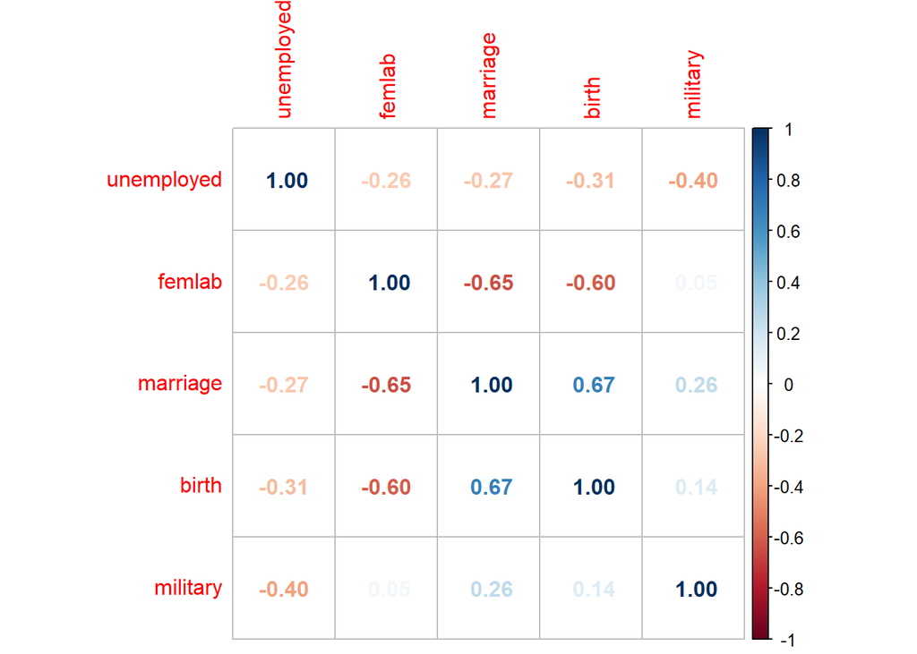

```r
corrplot(cor(X), method = "number")
```

3. Does the removal of the insignificant predictors from the model reduce the collinearity?

```r
 g2 <- update(g, . ~.-military)
 vif(g2)
```

```
## unemployed     femlab   marriage      birth
##   2.123735   3.598997   2.743709   2.571650
```

## Exercise 7 (Homework).

Using the macroeconomic dataset Longley, examine the multicollinearity.

1. `GNP.deflator`: GNP implicit price deflator.
2. `GNP`: Gross National Product.
3. `Unemployed`: number of unemployed.
4. `Armed.Forces`: number of people in the armed forces.
5. `Population`: ‘noninstitutionalized’ population ≥ 14 years of age.
6. `Year`: the year (time).
7. `Employed`: number of people employed.
1. Regress the response variable `Employed` against the remaining variables. Three of the predictors have large p-values but all are variables that might be expected to affect the response. Why aren’t they significant? Check the correlation matrix first (rounding to 3 digits for convenience). What do you think? Use the eigenvalue approach to explain the results.

```r
data("longley")
head(longley)
```

```
##      GNP.deflator     GNP Unemployed Armed.Forces Population Year Employed
## 1947         83.0 234.289      235.6        159.0    107.608 1947   60.323
## 1948         88.5 259.426      232.5        145.6    108.632 1948   61.122
## 1949         88.2 258.054      368.2        161.6    109.773 1949   60.171
## 1950         89.5 284.599      335.1        165.0    110.929 1950   61.187
## 1951         96.2 328.975      209.9        309.9    112.075 1951   63.221
## 1952         98.1 346.999      193.2        359.4    113.270 1952   63.639
```

```r
#Create a linear regression model
eco_model <- lm(Employed ~ ., longley)
summary(eco_model)
```

```
##
## Call:
## lm(formula = Employed ~ ., data = longley)
##
## Residuals:
##      Min       1Q   Median       3Q      Max
## -0.41011 -0.15767 -0.02816  0.10155  0.45539
##
## Coefficients:
##                Estimate Std. Error t value Pr(>|t|)
## (Intercept)  -3.482e+03  8.904e+02  -3.911 0.003560 **
## GNP.deflator  1.506e-02  8.492e-02   0.177 0.863141
## GNP          -3.582e-02  3.349e-02  -1.070 0.312681
## Unemployed   -2.020e-02  4.884e-03  -4.136 0.002535 **
## Armed.Forces -1.033e-02  2.143e-03  -4.822 0.000944 ***
## Population   -5.110e-02  2.261e-01  -0.226 0.826212
## Year          1.829e+00  4.555e-01   4.016 0.003037 **
## ---
## Signif. codes:  0 '***' 0.001 '**' 0.01 '*' 0.05 '.' 0.1 ' ' 1
##
## Residual standard error: 0.3049 on 9 degrees of freedom
## Multiple R-squared:  0.9955, Adjusted R-squared:  0.9925
## F-statistic: 330.3 on 6 and 9 DF,  p-value: 4.984e-10
```

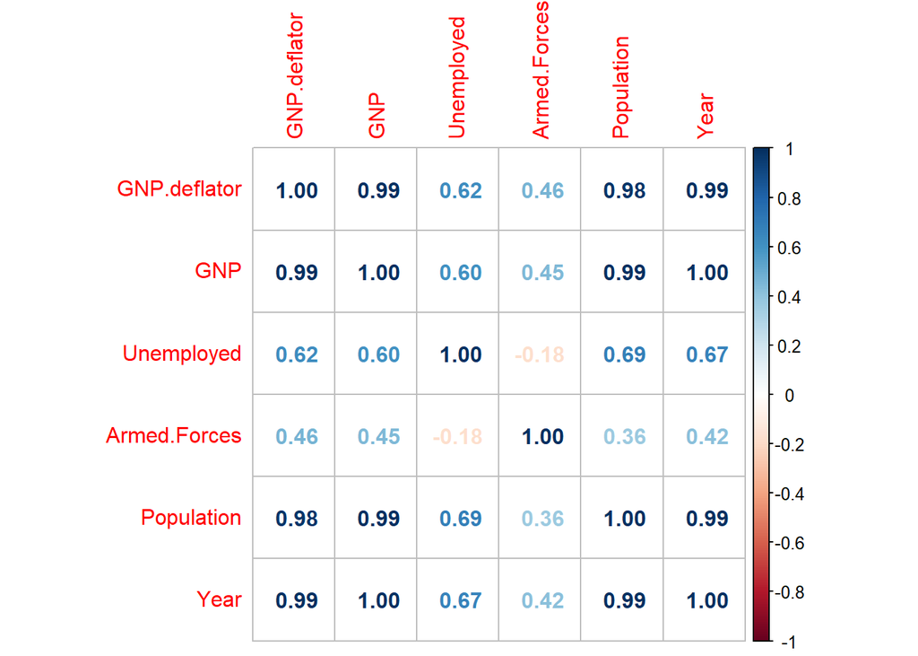

```r
corrplot(cor(longley[,-7]), method = "number")
```

```r
X <- as.matrix(longley[,-7])
e <- eigen(t(X) %*% X)
e$values
```

```
## [1] 6.665299e+07 2.090730e+05 1.053550e+05 1.803976e+04 2.455730e+01
## [6] 2.015117e+00
```

```r
sqrt(e$values[1]/e$values)
```

```
## [1]    1.00000   17.85504   25.15256   60.78472 1647.47771 5751.21560
```

There are several large pairwise correlations. We can see that there is a wide range in the eigenvalues and several condition numbers are large. This means that problems are being caused by more than just one linear combination.

2. Check the variance inflation factor for the model. Interpret the results and provide your suggestions.

```r
vif(eco_model)
```

```
## GNP.deflator          GNP   Unemployed Armed.Forces   Population         Year
##    135.53244   1788.51348     33.61889      3.58893    399.15102    758.98060
```

There’s very high variance inflation! For instance, we can interpret $\sqrt(1788.5134) = 42$ as telling us that the standard error for GNP is 42 times larger than it would have been without collinearity. How can we get rid of this problem? One way is to throw out some of the variables. Examine the full correlation matrix above. Notice only the variables `Unemployed` and `Armed.Forces` do not have extremely large pairwise correlations with the other variables. We should keep them and focus on the others for candidates for removal.

```r
eco_model1 <- update(eco_model,  ~ . - GNP , longley)
summary(eco_model1)
```

```
##
## Call:
## lm(formula = Employed ~ GNP.deflator + Unemployed + Armed.Forces +
##     Population + Year, data = longley)
##
## Residuals:
##      Min       1Q   Median       3Q      Max
## -0.47664 -0.12157 -0.01118  0.10669  0.50613
##
## Coefficients:
##                Estimate Std. Error t value Pr(>|t|)
## (Intercept)  -2.705e+03  5.182e+02  -5.220 0.000390 ***
## GNP.deflator -4.392e-02  6.503e-02  -0.675 0.514806
## Unemployed   -1.526e-02  1.600e-03  -9.538 2.45e-06 ***
## Armed.Forces -9.258e-03  1.906e-03  -4.856 0.000665 ***
## Population   -2.526e-01  1.259e-01  -2.006 0.072661 .
## Year          1.439e+00  2.742e-01   5.246 0.000375 ***
## ---
## Signif. codes:  0 '***' 0.001 '**' 0.01 '*' 0.05 '.' 0.1 ' ' 1
##
## Residual standard error: 0.307 on 10 degrees of freedom
## Multiple R-squared:  0.9949, Adjusted R-squared:  0.9924
## F-statistic: 390.5 on 5 and 10 DF,  p-value: 4.004e-11
```

```r
vif(eco_model1)
```

```
## GNP.deflator   Unemployed Armed.Forces   Population         Year
##    78.372376     3.557776     2.800835   122.047678   271.189670
```

```r
eco_model2 <- update(eco_model1,  ~ . - Year , longley)
summary(eco_model2)
```

```
##
## Call:
## lm(formula = Employed ~ GNP.deflator + Unemployed + Armed.Forces +
##     Population, data = longley)
##
## Residuals:
##      Min       1Q   Median       3Q      Max
## -0.65617 -0.25766 -0.00081  0.12135  1.22254
##
## Coefficients:
##               Estimate Std. Error t value Pr(>|t|)
## (Intercept)  13.781314   6.886470   2.001 0.070657 .
## GNP.deflator  0.207046   0.081376   2.544 0.027270 *
## Unemployed   -0.012412   0.002780  -4.465 0.000955 ***
## Armed.Forces -0.005968   0.003325  -1.795 0.100170
## Population    0.306601   0.123795   2.477 0.030755 *
## ---
## Signif. codes:  0 '***' 0.001 '**' 0.01 '*' 0.05 '.' 0.1 ' ' 1
##
## Residual standard error: 0.5671 on 11 degrees of freedom
## Multiple R-squared:  0.9809, Adjusted R-squared:  0.9739
## F-statistic: 141.1 on 4 and 11 DF,  p-value: 2.26e-09
```

```r
vif(eco_model2)
```

```
## GNP.deflator   Unemployed Armed.Forces   Population
##    35.970754     3.147600     2.497795    34.588299
```